# projekt_ML_Insurance

W kolejnym modelu umożliwiono nieliniowe dopasowanie zmiennych BMI oraz AGE, co poskutkowało lepszym dopasowaniem.

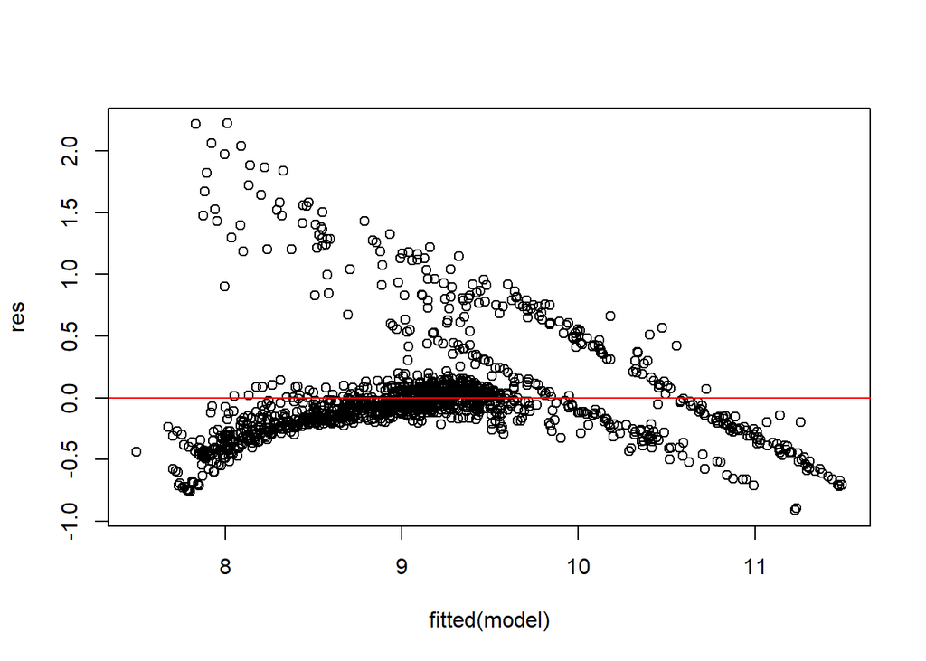

```r
model <- lm(
  charges_log ~ smoker * ns(bmi, 4) + ns(age, 3) + sex + region + children,
  data = df
)
sum_m <- summary(model)
res <- residuals(model)
plot(fitted(model), res)
abline(h = 0, col = "red")
```

```r
print(sum_m$r.squared)
```

```
[1] 0.7918176
```

W kolejnym kroku dodano interakcje między paleniem, a wiekiem. Ponownie poziom wyjaśnionej wariancji przez modelu wzrósł.

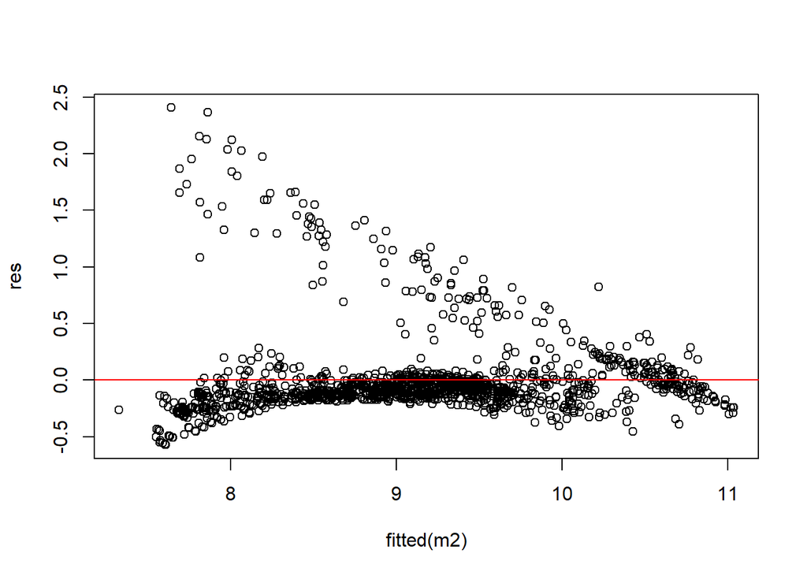

```r
m2 <- lm(charges_log ~ smoker * (ns(bmi,4) + ns(age,3)) + sex + region + children, data = df)
sum_m <- summary(m2)
res <- residuals(m2)
plot(fitted(m2), res)
abline(h = 0, col = "red")
```

```r
print(sum_m$r.squared)
```

```
[1] 0.8335717
```

Pomimo znacznego polepszenia struktury błędów, nadal widać znacząco niedoszacowane obserwacje.

```r
fit <- fitted(m2)
res <- residuals(m2)

top_idx <- order(abs(res), decreasing = TRUE)[1:100]
outliers <- cbind(row = top_idx,
                  df[top_idx, ],
                  fit = fit[top_idx],
                  resid = res[top_idx],
                  rstudent = rstudent(model)[top_idx],
                  cooks = cooks.distance(model)[top_idx])
head(outliers)
```

```
      row age    sex    bmi children smoker    region  charges charges_log
431   431  19   male 33.100        0     no southwest 23082.96   10.046850
517   517  20   male 35.310        1     no southeast 27724.29   10.230064
103   103  18 female 30.115        0     no northeast 21344.85    9.968566
1028 1027  23   male 18.715        0     no northwest 21595.38    9.980235
220   220  24 female 23.210        0     no southeast 25081.77   10.129896
1040 1039  19   male 27.265        2     no northwest 22493.66   10.020989
     is_male is_smoking      fit    resid rstudent      cooks
431        1          0 7.639933 2.406917 5.321225 0.01193020
517        1          0 7.862131 2.367933 5.342124 0.01484370
103        0          0 7.812055 2.156511 4.736089 0.01147624
1028       1          0 7.852856 2.127378 4.974847 0.02632525
220        0          0 8.006029 2.123868 4.895461 0.01003772
1040       1          0 7.982537 2.038452 4.514848 0.01283491
```

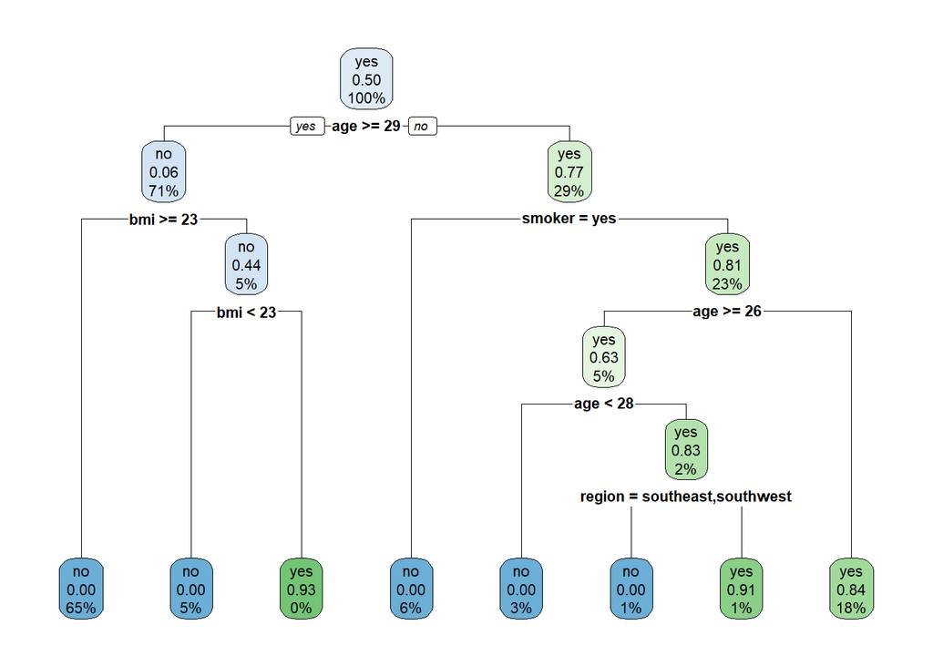

```r
aug <- augment(m2, data = df)
aug$upper <- as.integer(aug$.resid > 1.5)
aug$upper <- factor(aug$upper, levels = c(0,1), labels = c("no","yes"))
tree <- rpart(
  upper ~ smoker + region + children + sex + bmi + age,
  data = aug,
  method = "class",
  parms = list(prior = c(0.5, 0.5)),
  control = rpart.control(cp = 0.0001, minbucket = 5, minsplit = 10, maxdepth = 5)
)

rpart.plot(tree)
```

Jako, że w danych nie widać konkretnego powodu dla których grupy te mają tak wysokie opłaty, założono, że zbiór danych nie jest kompletny i istnieje dodatkowy czynnik, który nie został uwzględniony.

Powyższe wnioski na temat struktury modelu posłużą w dalszym etapie modelowaniu do zbudowania przepisów.

## 3.2 Przygotowanie danych

```r
df <- df %>%
  mutate(
    charges_log = log(charges),
    smoker  = factor(smoker),
    sex     = factor(sex),
    region  = factor(region),
    children = factor(children)
  )
```

## 3.3 Dodanie przepisu

```r
rec_base <- recipe(
  charges ~ smoker + bmi + age + sex + region + children,
  data = df
) |>
step_log(charges) |>
step_dummy(all_nominal_predictors()) |>
step_zv(all_predictors()) |>
step_normalize(all_numeric_predictors())

rec_smoke_interaction <- recipe(
  charges ~ smoker + bmi + age + sex + region + children,
  data = df
) |>
step_log(charges) |>
step_dummy(all_nominal_predictors()) |>
step_interact(terms = ~ starts_with("smoker_"):bmi) |>
step_zv(all_predictors()) |>
step_normalize(all_numeric_predictors())

rec_smoke_interaction_ns <- recipe(
  charges ~ smoker + bmi + age + sex + region + children,
  data = df
) |>
step_log(charges) |>
step_dummy(all_nominal_predictors()) |>
step_ns(age, deg_free=3) |>
step_ns(bmi, deg_free=4) |>
step_interact(terms = ~ starts_with("smoker_") : contains("_ns_")) |>
step_zv(all_predictors()) |>
step_normalize(all_numeric_predictors())
```

```r
recipes_list <- list(
  base = rec_base,
  smoke_inter = rec_smoke_interaction,
  smoke_inter_ns = rec_smoke_interaction_ns
)
```

## 3.4 Zdefiniowanie modeli

```r
lm_spec      <- linear_reg() |>  set_engine("lm")

ridge_spec   <- linear_reg(penalty = tune(), mixture = 0) |>  set_engine("glmnet")

rf_spec <- rand_forest(mtry = tune(), min_n = tune(), trees = 1000) |>
  set_engine("ranger") |>  set_mode("regression")

xgb_spec <- boost_tree(
  trees = 1000, learn_rate = tune(),
  tree_depth = tune(), min_n = tune(), loss_reduction = tune()
) |>  set_engine("xgboost")  |>  set_mode("regression")

models_list <- list(
  lm     = lm_spec ,
  ridge  = ridge_spec ,
  rf     = rf_spec,
  xgb    = xgb_spec
)
```

```r
wfs <- workflow_set( preproc = recipes_list, models = models_list, cross = TRUE )
```

```r
ridge_grid <- grid_regular(penalty(range = c(-4, 1)), levels = 20)

rf_grid <- grid_latin_hypercube(
  mtry(range = c(2L, 20L)),
  min_n(),
  size = 20
)

xgb_grid <- grid_latin_hypercube(
  learn_rate(), tree_depth(), min_n(), loss_reduction(),
  size = 25
)

ridge_ids <- wfs$wflow_id[grepl("_ridge$", wfs$wflow_id)]
rf_ids    <- wfs$wflow_id[grepl("_rf$",    wfs$wflow_id)]
xgb_ids   <- wfs$wflow_id[grepl("_xgb$",   wfs$wflow_id)]


wfs2 <- wfs
for (id in ridge_ids) wfs2 <- option_add(wfs2, id = id, grid = ridge_grid)
for (id in rf_ids)    wfs2 <- option_add(wfs2, id = id, grid = rf_grid)
for (id in xgb_ids)   wfs2 <- option_add(wfs2, id = id, grid = xgb_grid)
```

## 3.5 Ewaluacja modeli

```r
# 1) Podział na zbiór treningowy i testowy
spl <- initial_split(df, prop = 0.8)

folds <- vfold_cv(training(spl), v = 5)
metrics <- metric_set(rmse, mae, rsq)

ctrl_grid <- control_grid(
  save_workflow = TRUE,
  parallel_over = "resamples",
  verbose = TRUE
)

set.seed(123)
results <- workflow_map(
  wfs2,
  "tune_grid",
  resamples = folds,
  metrics   = metrics,
  control   = ctrl_grid,
  seed      = 123
)
```

```r
ranked <- rank_results(results)
ranked <- ranked |>  filter(.metric == "rmse") |>  arrange(mean)
print(ranked)
```

```
# A tibble: 198 × 9
   wflow_id         .config .metric  mean std_err     n preprocessor model  rank
   <chr>            <chr>   <chr>   <dbl>   <dbl> <int> <chr>        <chr> <int>
 1 smoke_inter_ns_… Prepro… rmse    0.398  0.0159     5 recipe       line…     1
 2 smoke_inter_rf   Prepro… rmse    0.400  0.0179     5 recipe       rand…     2
 3 smoke_inter_rf   Prepro… rmse    0.401  0.0175     5 recipe       rand…     3
 4 smoke_inter_rf   Prepro… rmse    0.402  0.0192     5 recipe       rand…     4
 5 smoke_inter_rf   Prepro… rmse    0.402  0.0195     5 recipe       rand…     5
 6 base_rf          Prepro… rmse    0.402  0.0180     5 recipe       rand…     6
 7 base_rf          Prepro… rmse    0.403  0.0193     5 recipe       rand…     7
 8 base_rf          Prepro… rmse    0.403  0.0180     5 recipe       rand…     8
 9 smoke_inter_rf   Prepro… rmse    0.404  0.0167     5 recipe       rand…     9
10 smoke_inter_rf   Prepro… rmse    0.404  0.0205     5 recipe       rand…    10
# ℹ 188 more rows
```

W następnym kroku wygenerowano predykcje dla 20% zbioru testowego

```r
# Wybór najlepszych konfiguracji
final_tbl <- results |>
  mutate(
    best = map(result, ~ select_best(.x, metric = "rmse")),
    wf   = map2(info, best, ~ finalize_workflow(.x$workflow[[1]], .y)),
    last = map(wf, ~ last_fit(.x, split = spl))
  )

# Zebranie predykcji
test_preds <- final_tbl |>
  mutate(preds = map(last, collect_predictions)) |>
  select(wflow_id, preds) |>
  unnest(preds)
```

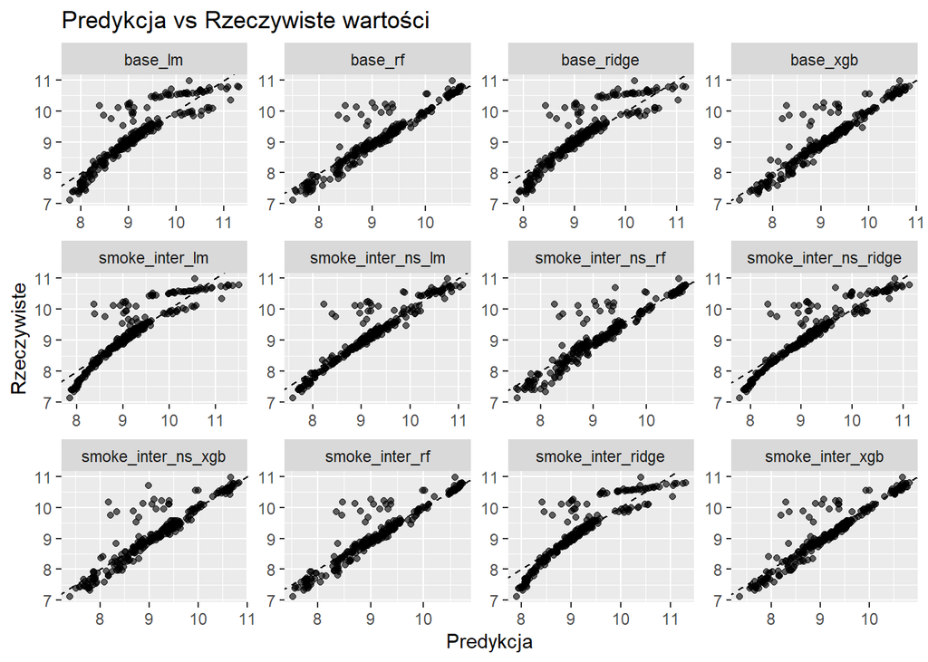

```r
# Wykres Predykcja vs Rzeczywiste
ggplot(test_preds, aes(x = .pred, y = charges)) +
  geom_point(alpha = 0.6) +
  geom_abline(slope = 1, intercept = 0, linetype = "dashed") +
  facet_wrap(~ wflow_id, scales = "free") +
  labs(x = "Predykcja", y = "Rzeczywiste", title = "Predykcja vs Rzeczywiste wartości")
```

# 4 Wnioski

Poprawnie zbudowany model regresji liniowej osiągnął lepsze wyniki niż bardziej zaawansowane metody.